# Praca domowa

Jakub Bondyra

8 października 2017

## Wstęp

Obiektem mojego zainteresowania były dane dotyczące Korei Północnej. Na odpowiednich wizualizacjach chcę pokazać burzliwe wydarzenia dotyczące tego kraju na przestrzeni ostatnich kilku lat - od 2013 roku do chwili obecnej.

Najtrudniejszą częścią zadania było zdecydowanie pozyskanie danych. Korea Północna jest krajem bardzo zamkniętym, co powoduje, że nie jest dostępnych zbyt wiele źródeł danych dotyczących interesujących mnie zagadnień.

Wszelkie wykorzystane źródła zostają podane na końcu tego dokumentu. Ukrywam ponadto kod służący do wygenerowania wykresów - jest on oczywiście dostępny w źródłowym pliku .Rmd.

### Incydenty militarne i wydźwięk w mediach

Poniżej przedstawiam wykres liczby artykułów dotyczących Korei Północnej w określonym miesiącu, które ukazały się w portalu gazety New York Times na przestrzeni ostatnich kilku lat. Nie trzeba się zbytnio domyślać, o czym pisano w takich artykułach - dlatego dodatkowo nanoszę na wykres incydenty militarne i próby atomowe, które odbywały się w danych miesiącach.

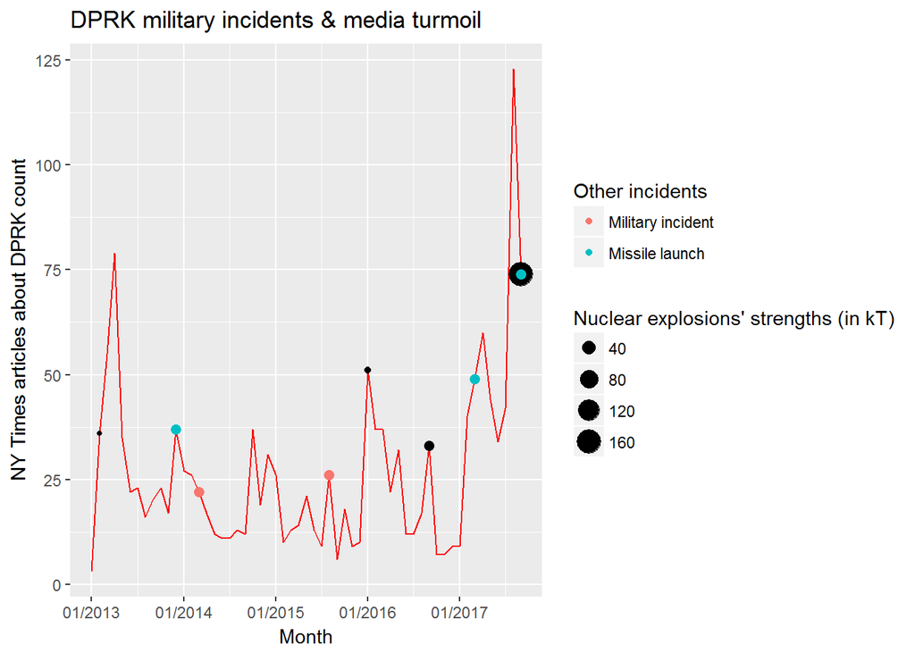

### Incydenty militarne i pomoc humanitarna

Bardzo prawdopodobne jest, że sporo z incydentów prowokowanych przez Koreę ma wpływ na pomoc humanitarną, którą dostarczają kraje zewnętrzne. W tym celu pokazuję poniżej wartości pomocy humanitarnej udzielonej Korei Północnej przez resztę świata wraz z incydentami przedstawianymi na poprzednim wykresie.

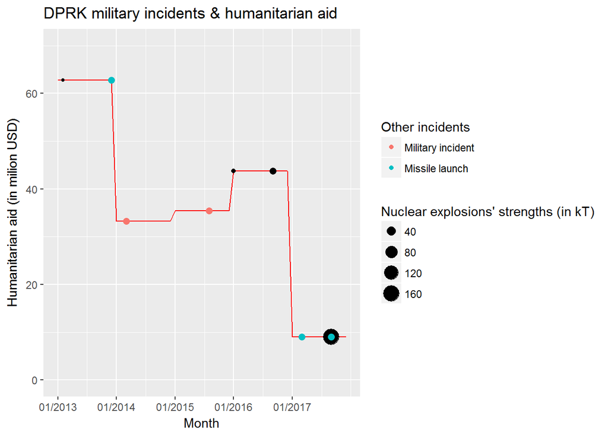

Wartość pomocy udzielonej w 2017 roku nie jest pełna. Nie zanosi się jednak na to, że wzrośnie ona znacząco.

### Opady deszczu i klęski żywiołowe

Przedstawiam również wykres kompletnie apolityczny - pokazujący rozkład opadów atmosferycznych w stolicy Korei Północnej wraz z informacjami o katastrofalnych suszach i powodziach, które nawiedziły ten kraj.

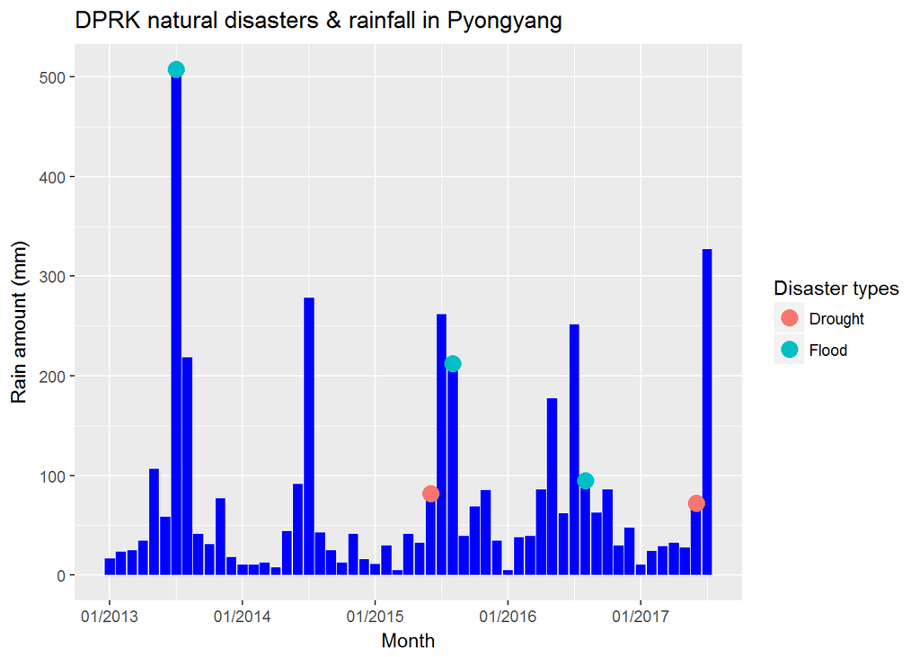

### Produkcja ryżu i klęski żywiołowe

Poniżej przedstawiam również wykres pokazujący produkcję ryżu w Korei Północnej w zależności od klęsk żywiołowych na przestrzeni ostatnich kilku lat.

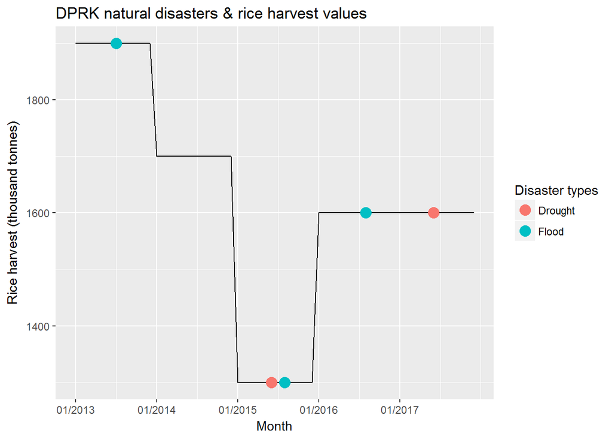

### Źródła danych

Artykuły dotyczące Korei Północnej:

*www.nytimes.com/topic/destination/north-korea*

Dane ilościowe dotyczące upraw:

*www.fas.usda.gov*

Próby atomowe i incydenty militarne w Korei:

*www.en.wikipedia.org/wiki/List_of_nuclear_weapons_tests_of_North_Korea*

*www.en.wikipedia.org/wiki/North_Korea%E2%80%93South_Korea_relations*

Powodzie i susze w Korei Północnej:

*www.reliefweb.int/country/prk*

Klimat Pyongyangu:

*www.worldweatheronline.com/pyongyang-weather-averages/kp.aspx*

Pomoc humanitarna:

*www.northkoreaintheworld.org/humanitarian/humanitarian-aid*

*www.nytimes.com/topic/destination/north-korea*